# Lab Meeting 11/13

2020-11-09

# 1 Herring Updates

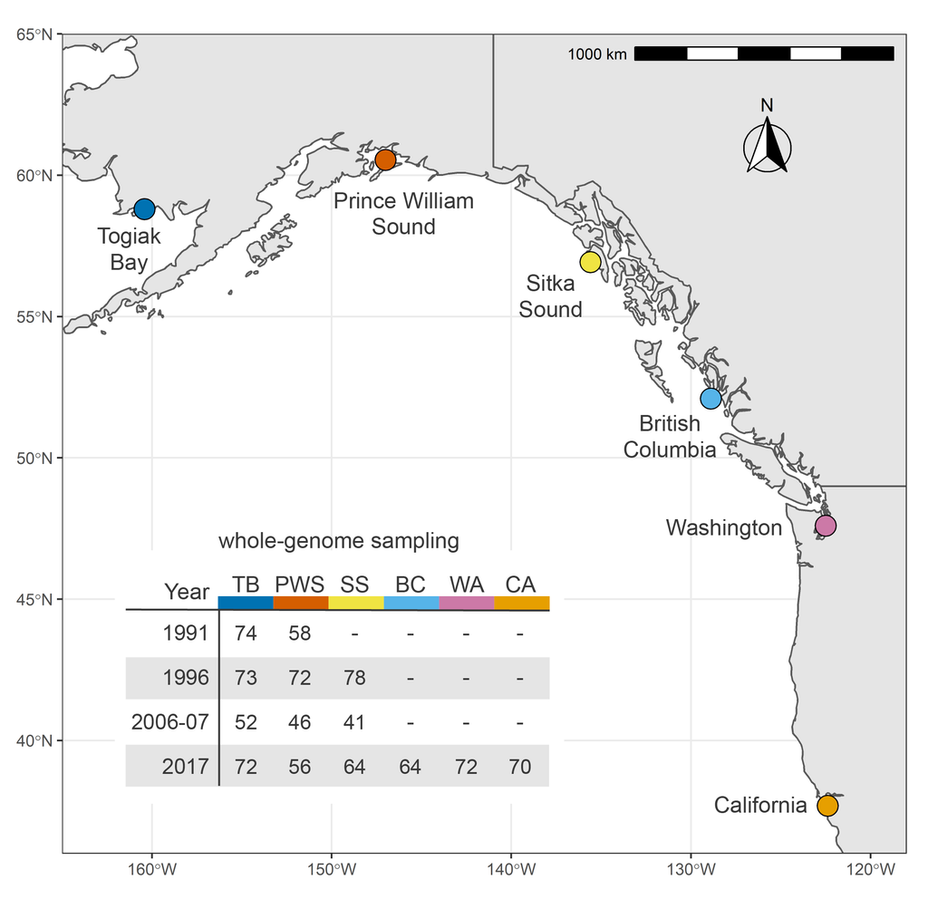

## 1.1 Do we see changes in population size consistent with collapse and lack of recovery in Prince William Sound?

These are results that I showed last time. Effective population size Ne estimated using nucleotide diversity and mutation rate (2.0e-9).

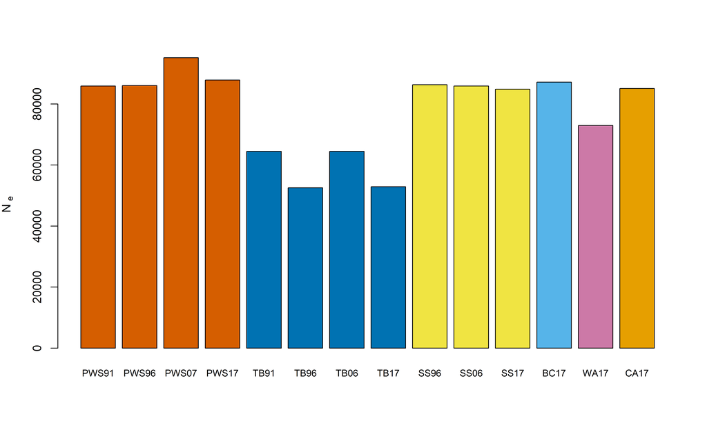

But this is a long-term estimate of Ne. We can also estimate short term Ne using temporal sampling.

Suppose we have an isolated random mating population with discrete generations and we wish to measure its (average) Ne during a certain period of time. We take two samples from the population, the first sample at the beginning (generation 0) and the second sample at the end (generation t) of the period of time. The two samples are genotyped to estimate allele frequencies. Then Ne = t / F where F is standardized variance in the temporal changes of allele frequency.

Below, we can see variance in allele frequency change for Prince William Sound, Sitka Sound, and Togiak Bay populations.

Higher variance in allele frequency changes corresponds to lower estimate of Ne.

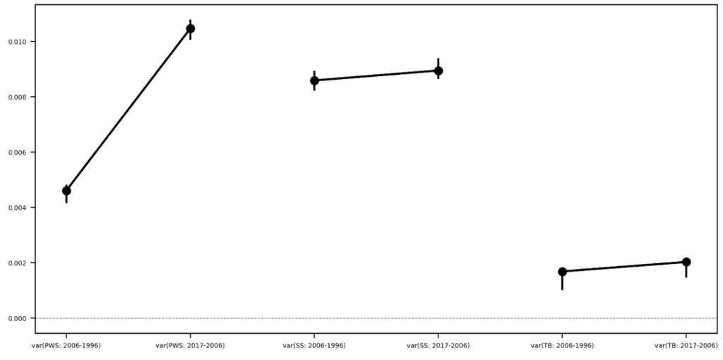

Does this line up with our expectations?

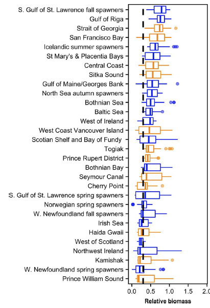

## 1.2 Loss of function mutations

Given that PWS experienced a population bottleneck, we might expect that deleterious alleles rose to higher frequencies in PWS relative to healthy populations due to genetic drift.

Step 1. Measure per-site Fst (as opposed to windowed Fst) to look at divergence between (PWS vs. healthy populations) at individual sites.

Step 2. Use the awesome Variant Effect Predictor tool from Ensembl to identify deleterious alleles (particularly loss-of-function alleles)

### 1.2.1 Per-site Fst Post-collapse PWS populations vs. NE Pacific populations

(PWS96 + PWS07 + PWS17) vs. (SS96 + SS06 + SS17 + BC17 + WA17)

```
## [1] "Fst range"
## [1] 0.0000000 0.5197319
## [1] "Fst mean"
## [1] 0.004171201
```

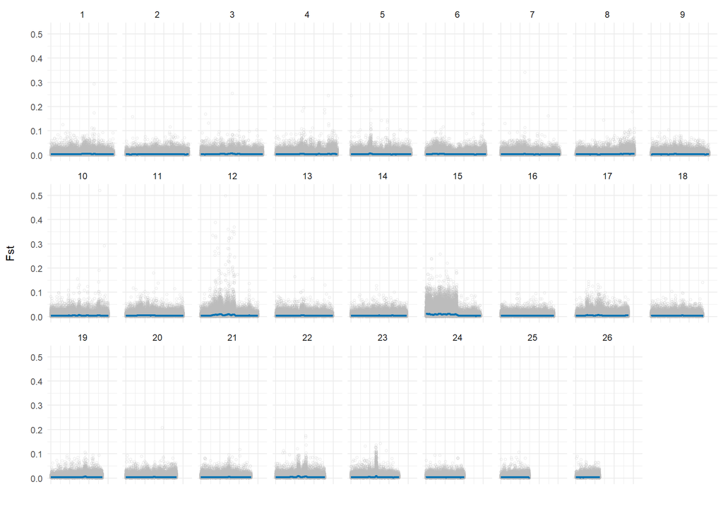

### 1.2.2 contemporary PWS vs. contemporary NE Pacific populations

(PWS17) vs. (SS17 + BC17 + WA17)

```
## [1] "Fst range"
## [1] 0.0000000 0.5437961
## [1] "Fst mean"
## [1] 0.0108166
```

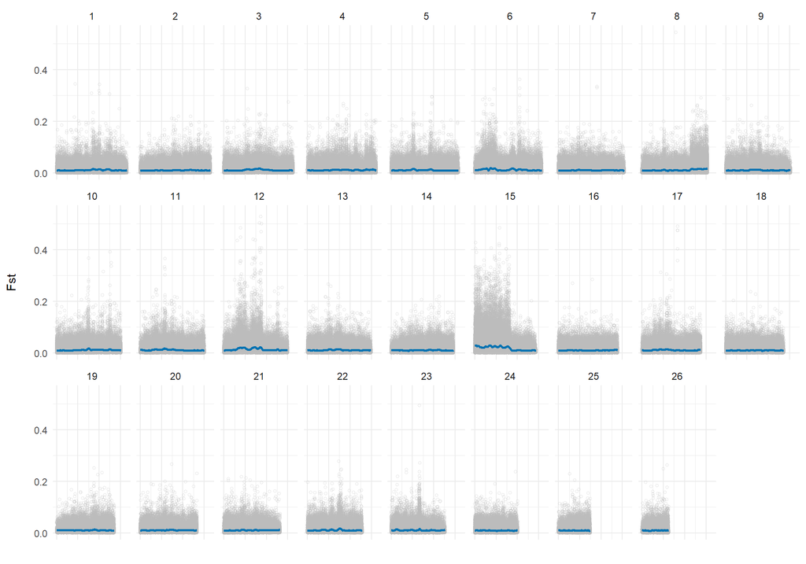

### 1.2.3 PWS pre-collapse vs. post-collapse

```
## [1] "Fst range"
## [1] 0.000000 0.635107
## [1] "Fst mean"
## [1] 0.02671783
```

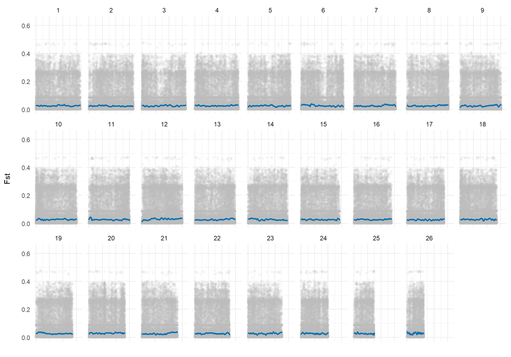

### 1.2.4 Variant Effect Predictor VEP

Ensemble resource. Input is:

chromosome position Ref_Allele Alt_Allele

VEP outputs the effect of SNP in coding region.  
Annotations relevant to LoF:  
stop_gained  
start_lost  
stop_lost  
missense

```
## stop gained alleles: 1900
## start lost alleles: 394
## stop lost alleles: 279
## missense alleles: 138677
```

### 1.2.5 Allele frequencies for each population

Estimate allele frequencies for each population with ANGSD

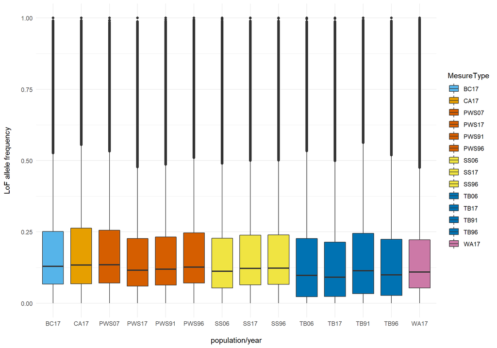

```
## [1] "anova for all populations"
```

```
##                   Df Sum Sq Mean Sq F value Pr(>F)
## maf_stack$ind     13     57   4.403   132.5 <2e-16 ***
## Residuals     368844  12262   0.033
## ---
## Signif. codes:  0 '***' 0.001 '**' 0.01 '*' 0.05 '.' 0.1 ' ' 1
```

```
##   Tukey multiple comparisons of means
##     95% family-wise confidence level
##
## Fit: aov(formula = maf_stack$value ~ maf_stack$ind)
##
## $`maf_stack$ind`
##                      diff           lwr           upr     p adj
## PWS96-PWS91  8.741897e-03  0.0034144457  0.0140693482 0.0000034
## PWS07-PWS91  1.335680e-02  0.0080293450  0.0186842475 0.0000000
## PWS17-PWS91 -2.985315e-03 -0.0083127659  0.0023421366 0.8381231
## TB91-PWS91  -7.299032e-03 -0.0126264831 -0.0019715805 0.0003705
## TB96-PWS91  -1.936574e-02 -0.0246931875 -0.0140382849 0.0000000
## TB06-PWS91  -1.931083e-02 -0.0246382778 -0.0139833753 0.0000000
## TB17-PWS91  -2.522188e-02 -0.0305493343 -0.0198944318 0.0000000
## SS96-PWS91   4.879085e-03 -0.0004483665  0.0102065360 0.1141904
## SS06-PWS91  -6.464788e-03 -0.0117922396 -0.0011373371 0.0037257
## SS17-PWS91   3.096882e-03 -0.0022305691  0.0084243335 0.7989543
## BC17-PWS91   1.047317e-02  0.0051457226  0.0158006251 0.0000000
## WA17-PWS91  -8.059049e-03 -0.0133865008 -0.0027315982 0.0000346
## CA17-PWS91   1.705363e-02  0.0117261791  0.0223810817 0.0000000
## PWS07-PWS96  4.614899e-03 -0.0007125520  0.0099423506 0.1751851
## PWS17-PWS96 -1.172721e-02 -0.0170546629 -0.0063997603 0.0000000
## TB91-PWS96  -1.604093e-02 -0.0213683800 -0.0107134775 0.0000000
## TB96-PWS96  -2.810763e-02 -0.0334350844 -0.0227801819 0.0000000
## TB06-PWS96  -2.805272e-02 -0.0333801748 -0.0227252723 0.0000000
## TB17-PWS96  -3.396378e-02 -0.0392912313 -0.0286363287 0.0000000
## SS96-PWS96  -3.862812e-03 -0.0091902635  0.0014646390 0.4568497
## SS06-PWS96  -1.520669e-02 -0.0205341365 -0.0098792340 0.0000000
## SS17-PWS96  -5.645015e-03 -0.0109724660 -0.0003175635 0.0259496
## BC17-PWS96   1.731277e-03 -0.0035961743  0.0070587282 0.9983690
## WA17-PWS96  -1.680095e-02 -0.0221283977 -0.0114734952 0.0000000
## CA17-PWS96   8.311733e-03  0.0029842822  0.0136391847 0.0000149
## PWS17-PWS07 -1.634211e-02 -0.0216695622 -0.0110146596 0.0000000
## TB91-PWS07  -2.065583e-02 -0.0259832793 -0.0153283768 0.0000000
## TB96-PWS07  -3.272253e-02 -0.0380499837 -0.0273950812 0.0000000
## TB06-PWS07  -3.266762e-02 -0.0379950741 -0.0273401716 0.0000000
## TB17-PWS07  -3.857868e-02 -0.0439061306 -0.0332512281 0.0000000
## SS96-PWS07  -8.477712e-03 -0.0138051628 -0.0031502603 0.0000085
## SS06-PWS07  -1.982158e-02 -0.0251490358 -0.0144941333 0.0000000
## SS17-PWS07  -1.025991e-02 -0.0155873653 -0.0049324628 0.0000000
```

[output cut: 43 more lines]

```
## SS06-SS96   -1.134387e-02 -0.0166713243 -0.0060164218 0.0000000
## SS17-SS96   -1.782203e-03 -0.0071096538  0.0035452487 0.9978076
## BC17-SS96    5.594089e-03  0.0002666379  0.0109215404 0.0289370
## WA17-SS96   -1.293813e-02 -0.0182655855 -0.0076106829 0.0000000
## CA17-SS96    1.217455e-02  0.0068470944  0.0175019969 0.0000000
## SS17-SS06    9.561671e-03  0.0042342192  0.0148891218 0.0000002
## BC17-SS06    1.693796e-02  0.0116105109  0.0222654135 0.0000000
## WA17-SS06   -1.594261e-03 -0.0069217124  0.0037331901 0.9993123
## CA17-SS06    2.351842e-02  0.0181909675  0.0288458700 0.0000000
## BC17-SS17    7.376292e-03  0.0020488404  0.0127037429 0.0002945
## WA17-SS17   -1.115593e-02 -0.0164833829 -0.0058284804 0.0000000
## CA17-SS17    1.395675e-02  0.0086292969  0.0192841995 0.0000000
## WA17-BC17   -1.853222e-02 -0.0238596746 -0.0132047721 0.0000000
## CA17-BC17    6.580457e-03  0.0012530053  0.0119079078 0.0027579
## CA17-WA17    2.511268e-02  0.0197852286  0.0304401312 0.0000000
```

```
## [1] "anova for focal populations:"
```

```
## [1] "PWS91" "PWS96" "PWS07" "PWS17"
```

```
##                   Df Sum Sq Mean Sq F value Pr(>F)
## maf_stack$ind      3      5  1.5141   47.97 <2e-16 ***
## Residuals     105384   3327  0.0316
## ---
## Signif. codes:  0 '***' 0.001 '**' 0.01 '*' 0.05 '.' 0.1 ' ' 1
```

```
##   Tukey multiple comparisons of means
##     95% family-wise confidence level
##
## Fit: aov(formula = maf_stack$value ~ maf_stack$ind)
##
## $`maf_stack$ind`
##                     diff           lwr           upr     p adj
## PWS96-PWS91  0.008741897  0.0047650689  0.0127187250 0.0000001
## PWS07-PWS91  0.013356796  0.0093799682  0.0173336243 0.0000000
## PWS17-PWS91 -0.002985315 -0.0069621427  0.0009915134 0.2160179
## PWS07-PWS96  0.004614899  0.0006380713  0.0085917273 0.0152246
## PWS17-PWS96 -0.011727212 -0.0157040396 -0.0077503836 0.0000000
## PWS17-PWS07 -0.016342111 -0.0203189389 -0.0123652829 0.0000000
```

```
## [1] "anova for focal populations:"
```

```
## [1] "PWS96" "PWS07" "PWS17" "SS96"  "SS06"  "SS17"
```

```
##                   Df Sum Sq Mean Sq F value Pr(>F)
## maf_stack$ind      5      7   1.412   44.17 <2e-16 ***
## Residuals     158076   5054   0.032
## ---
## Signif. codes:  0 '***' 0.001 '**' 0.01 '*' 0.05 '.' 0.1 ' ' 1
```

```
##   Tukey multiple comparisons of means
##     95% family-wise confidence level
##
## Fit: aov(formula = maf_stack$value ~ maf_stack$ind)
##
## $`maf_stack$ind`
##                     diff           lwr           upr     p adj
## PWS07-PWS96  0.004614899  0.0001752944  0.0090545042 0.0361245
## PWS17-PWS96 -0.011727212 -0.0161668165 -0.0072876067 0.0000000
## SS96-PWS96  -0.003862812 -0.0083024171  0.0005767926 0.1301229
## SS06-PWS96  -0.015206685 -0.0196462902 -0.0107670804 0.0000000
## SS17-PWS96  -0.005645015 -0.0100846196 -0.0012054099 0.0039443
## PWS17-PWS07 -0.016342111 -0.0207817158 -0.0119025060 0.0000000
## SS96-PWS07  -0.008477712 -0.0129173164 -0.0040381067 0.0000008
## SS06-PWS07  -0.019821585 -0.0242611895 -0.0153819797 0.0000000
## SS17-PWS07  -0.010259914 -0.0146995189 -0.0058203092 0.0000000
## SS96-PWS17   0.007864399  0.0034247945  0.0123040042 0.0000066
## SS06-PWS17  -0.003479474 -0.0079190786  0.0009601312 0.2223383
## SS17-PWS17   0.006082197  0.0016425920  0.0105218017 0.0013267
## SS06-SS96   -0.011343873 -0.0157834779 -0.0069042682 0.0000000
## SS17-SS96   -0.001782203 -0.0062218074  0.0026574023 0.8629652
## SS17-SS06    0.009561671  0.0051220656  0.0140012754 0.0000000
```